# Meu primeiro documento em R Markdown

2022-05-25

## **O primeiro documento em R Markdown**

- Para iniciar click em File<New file<R Markdown

[figure not shown]

- Se for necessário, você deverá instalar os pacotes requeridos. Click sim e o Rstudio instalará para você.
- Existe a opção de escolher se deseja criar um documento, uma apresentação de slides ou até mesmo uma app (shiny).
- Você pode mudar o tipo de documento gerado por meio da linha de saída do cabeçário, ou através da seleção de saída do botão knit abaixo do menu.
- Neste exemplo vamos criar um documento.

Digite o título do teu documento, o nome do autor e escolha uma opção de saída (HTML, PDF ou Word).  
E aperte ok!

[figure not shown]

[figure not shown]

## Embutindo um código em R

```
Isto é o que se considera "chunk" do código do R Markdown
```

- Para ocultar o resultado do código de entrada, use echo=FALSE. ’’’{r, echo=FALSE}
- Para mostrar apenas o código usado, use eval=FALSE. ’’’{r, eval=FALSE}
- Para rodar o Código sem mostrar a entrada ou saída, use include=FALSE. ’’’{r, include=FALSE}

```r
getwd()
```

```
## [1] "C:/Users/hp/Documents/CURSO DE ESTATISTICA PARA UFPR 2022/material do curso - apostila e slids/slids/R-Markdown"
```

```r
setwd("C:/Users/hp/Documents/CURSO DE ESTATISTICA PARA UFPR 2022/material do curso - apostila e slids/apostila/Exemplos R Markdown 1")
acaro_morango <- read.table("acaro.csv", header=T,  sep=";")
head(acaro_morango)
```

```
##   Total_acaro_praga Total_acaro_predador     tratamento
## 1                 0                    0           Buva
## 2                 0                    0 Corda_de_viola
## 3                 0                    3  dente_de_leao
## 4                 0                    0  erva_de_bicho
## 5                 0                    0  erva_de_touro
## 6                 0                    0     erva_macia
```

```r
names(acaro_morango)
```

```
## [1] "Total_acaro_praga"    "Total_acaro_predador" "tratamento"
```

## Podemos adicionar gráficos!

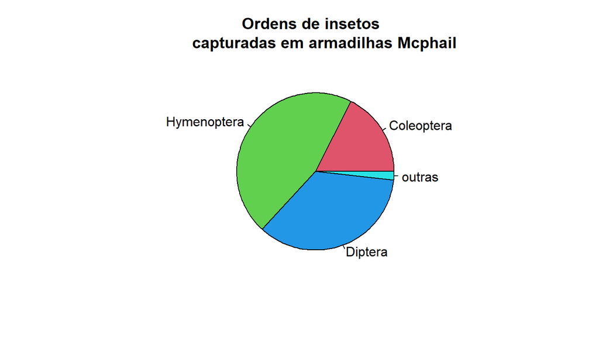

```r
x2 <- c(10, 26, 20, 1)
n2 <- c("Coleoptera", "Hymenoptera", "Diptera", "outras")
c2 <- c(2,3,4,5)
pie(x2, labels = n2, col = c2, main = "Ordens de insetos
    capturadas em armadilhas Mcphail")
```

## Podemos incluir figuras!

```
Existem dois modos:
```

1. Digite: ! [ ] (figuras/nome da figura.png). Deste modo a figura vai aparecer no local onde você escreveu este código. **Importante** ter uma pasta com as figuras salvas no teu diretório!
2. Apertar o botão inserir e clicar em figura. Ali vai abrir a janela onde será possivel achar teu arquivo seja do computador ou internet.

EXEMPLO:

[figure not shown]

## Opções para rodar o documento – botão Run

[figure not shown]

Ali existem opções variadas para ir rodando trechos do script ou apenas partes deste.

## **PDF e LaTeX**

- Para **knit** um slide em PDF será necessario instalar LaTeX no teu computador.
- O LaTeX é um programa de edição de texto, o qual é usado para converter R Markdown no formato de texto para PDF.

### *Baixando e instalando LaTeX*

- LaTeX é livre.
  - Procure em: https://www.tug.org/begin.html para descarregar
- Dependendo de tua velocidade de conecção com internet, esta instalação pode ser um tanto lenta, devido ao tamanho do documento que se deve baixar.

## **Considerações finais**

- R Markdown é uma boa ferramenta para gerar documentos, especialmente para publicar em internet;
- Exige no inicio um pouco de esforço para aprender a usá-lo.
- Para maiores informações sobre o R Markdown visite o site indicado:
  - http://rmarkdown.rstudio.com/

## Obrigada pela atenção

**Emily Silva Araujo**  
*araujosemily@gmail.com*